# Household Travel Survey: Commuting Data

Suzanne Childress & Mary Richards

March 17, 2021

This report presents preliminary findings for commuting trends based on the Household Travel Survey (2019), a survey conducted every other year to determine travel patterns for individuals living within PSRC’s four-county jurisdiction.

## Commuting Trips

This analysis will focus on the commute trips of people who usually work outside the home.

- **What is the share of trips made for “commuting”?**

Commuting will be defined as the trips where one of the trip ends is a regular workplace - based on the survey logic, the origin or destination purpose is ‘Went to primary workplace’

Based on the total number of trips (72,855) documented as part of the 2019 survey results, 20% (14,501) were recorded as being commute trips. When trip weights are taken into consideration, **24%** of the trips in the region are for commuting.  
This value reflects a similar finding in the National Household Travel Survey (2017). In “Summary of Travel Trends” (https://nhts.ornl.gov/assets/2017_nhts_summary_travel_trends.pdf, pg. 22), Table 6c shows that households annually make 450 vehicle trips to/from work out of the total 1,865 trips for all purposes, or 24%.

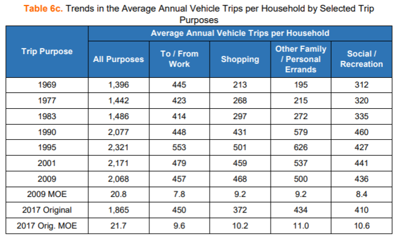

This summary also reports that about 28% of VMT are commute-related (2017 adjusted).

## Defining Commuters

This subset of the respondents are based on the following survey questions:

- **“Primary type of employment?”**
- **“Please answer for your primary jobs where you work the most hours per week”**
  - “Usual work location?”

For this analysis, commuters are those with:

1. full-time or part-time paid employment or those who identified as self-employed with workplaces.
2. workplaces that are not at home
3. commute distances less than 200 miles

| employment | n | Weighted_2019 | Weighted_Percent |
| --- | --- | --- | --- |
| Employed full time (35+ hours/week, paid) | 2319 | 1354787 | 85.17 |
| Employed part time (fewer than 35 hours/week, paid) | 288 | 196916 | 12.38 |
| Self-employed | 97 | 39074 | 2.46 |

| workplace | n | Weighted_2019 | Weighted_Percent |
| --- | --- | --- | --- |
| Drives for a living (e.g., bus driver, salesperson) | 48 | 57289 | 3.60 |
| Usually the same location (outside home) | 2313 | 1284117 | 80.72 |
| Workplace regularly varies (different offices or jobsites) | 343 | 249371 | 15.68 |

Out of a total 5,711 people who responded to the 2019 travel survey, **2,704** are individuals employed outside of the home who commute with automobile commutes of less than 200 miles. The commute distance limit was intended to remove outliers.

## General commute statistics

### Methodology

The following statistics uses the fields `commute_auto_Distance` and `commute_auto_time` to summarize the distribution of distance to work and commute duration. It is important to note that only 2019 data has the distances.  
The main question we will be attempting to answer is: **How does the distance or commute time from home to your primary workplace vary by income and race?**  
Commute travel times and distances were found using the google distance matrix api (https://developers.google.com/maps/documentation/distance-matrix/overview). Survey respondents reported home locations and work locations for all household workers. Google travel time and distance data were pulled from the api given these locations, assuming an 8 am travel time in April of 2019.

### **Commute distance**

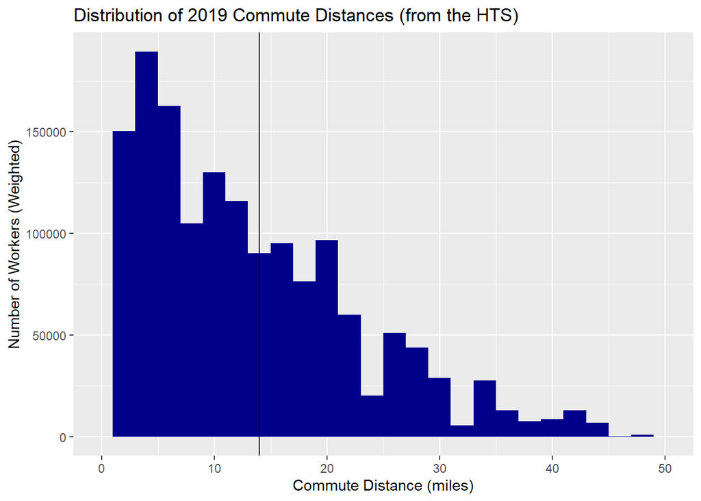

*The vertical line at x=**13.97 miles** represents the mean distance traveled by workers*

Share of workers in the region with auto commutes

| dist_bins | HouseholdWeight | WeightedPercent | WeightedAvg | min | max | SampleSize | SamplePercent |
| --- | --- | --- | --- | --- | --- | --- | --- |
| <3 miles (very short) | 209061 | 13.14 | 1.62 | 0.01180605 | 2.998736 | 817 | 30.21 |
| 3-10 miles (short) | 520898 | 32.74 | 6.13 | 3.00122193 | 9.989160 | 968 | 35.80 |
| 10-20 miles (average) | 482898 | 30.36 | 14.48 | 10.00469447 | 19.781967 | 618 | 22.86 |
| 20-50 miles (long) | 344184 | 21.64 | 27.57 | 20.05537040 | 48.268721 | 276 | 10.21 |
| 50+ miles (very long) | 33737 | 2.12 | 65.69 | 52.02304423 | 102.867348 | 25 | 0.92 |

#### 1. Income

The average commuting distance by income:

| hhincome_detailed | n | Group_weight | Weighted_percent | Weighted_avg | sd | se | CI_90 | CI_95 |
| --- | --- | --- | --- | --- | --- | --- | --- | --- |
| Under $10,000 | 12 | 12928 | 0.81 | 6.45 | 7.606 | 2.196 | 3.612 | 4.303 |
| $10,000-$24,999 | 70 | 56470 | 3.55 | 7.18 | 8.335 | 0.996 | 1.639 | 1.953 |
| $25,000-$34,999 | 111 | 60586 | 3.81 | 10.41 | 7.225 | 0.686 | 1.128 | 1.344 |
| $35,000-$49,999 | 199 | 113998 | 7.17 | 11.85 | 9.047 | 0.641 | 1.055 | 1.257 |
| $50,000-$74,999 | 366 | 211106 | 13.27 | 12.41 | 11.662 | 0.610 | 1.003 | 1.195 |
| $75,000-$99,999 | 375 | 190867 | 12.00 | 14.75 | 11.239 | 0.580 | 0.955 | 1.138 |
| $100,000-$149,999 | 602 | 313578 | 19.71 | 15.23 | 9.935 | 0.405 | 0.666 | 0.794 |
| $150,000-$199,999 | 315 | 254263 | 15.98 | 17.82 | 11.373 | 0.641 | 1.054 | 1.256 |
| $200,000-$249,999 | 233 | 117506 | 7.39 | 15.29 | 8.479 | 0.555 | 0.914 | 1.089 |
| $250,000 or more | 220 | 78718 | 4.95 | 14.91 | 9.631 | 0.649 | 1.068 | 1.273 |

[output cut: 1 more lines]

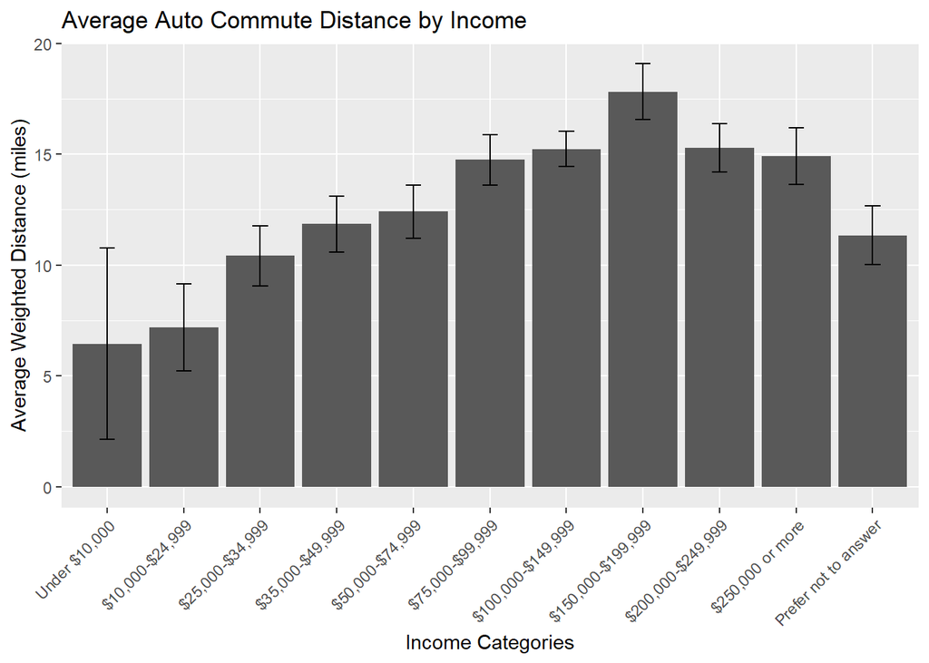

#### 2. Race

People who identify as white have the longest commutes (average ~15 miles). The margins of error for African American and Hispanic groups are relatively large due to the small sample sizes.

The average commuting distance by race:

| race_category | n | Group_weight | Weighted_percent | Weighted_avg | sd | se | CI_90 | CI_95 |
| --- | --- | --- | --- | --- | --- | --- | --- | --- |
| African American | 66 | 59789 | 3.76 | 11.92 | 9.614 | 1.183 | 1.947 | 2.319 |
| Asian | 382 | 170852 | 10.74 | 14.19 | 8.860 | 0.453 | 0.746 | 0.889 |
| Hispanic | 122 | 86397 | 5.43 | 12.77 | 9.049 | 0.819 | 1.348 | 1.606 |
| White Only | 1873 | 957188 | 60.17 | 15.08 | 10.571 | 0.244 | 0.402 | 0.479 |
| Other | 119 | 98030 | 6.16 | 8.83 | 9.046 | 0.829 | 1.364 | 1.625 |
| Missing | 142 | 218520 | 13.74 | 12.33 | 10.964 | 0.920 | 1.514 | 1.803 |

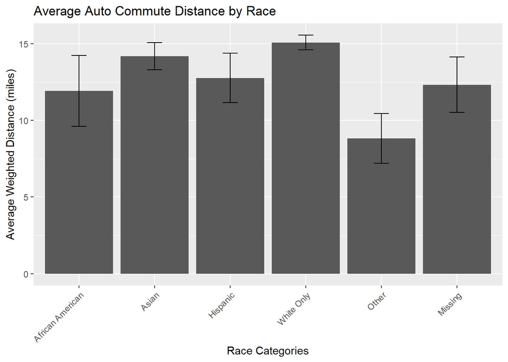

##### Aggregated Race

Because of small sample sizes, some of the respondents have been aggregated.

###### African American and Hispanic

For this analysis, respondents who identified as African American and Hispanic were aggregated.

Although the margin of error for the POC group is better than when African American- and Hispanic-identifying individuals were analyzed separately, it is still not distinct from respondents identifying as Asian.

The average commuting distance by race:

| race_agg_1 | n | Group_weight | Weighted_percent | Weighted_avg | sd | se | CI_90 | CI_95 |
| --- | --- | --- | --- | --- | --- | --- | --- | --- |
| Non-Asian POC | 188 | 146186 | 9.19 | 12.42 | 9.229 | 0.673 | 1.107 | 1.319 |
| White Only | 1873 | 957188 | 60.17 | 15.08 | 10.571 | 0.244 | 0.402 | 0.479 |
| Other | 119 | 98030 | 6.16 | 8.83 | 9.046 | 0.829 | 1.364 | 1.625 |
| Missing | 142 | 218520 | 13.74 | 12.33 | 10.964 | 0.920 | 1.514 | 1.803 |
| NA | 382 | 170852 | 10.74 | 14.19 | 8.860 | 0.453 | 0.746 | 0.889 |

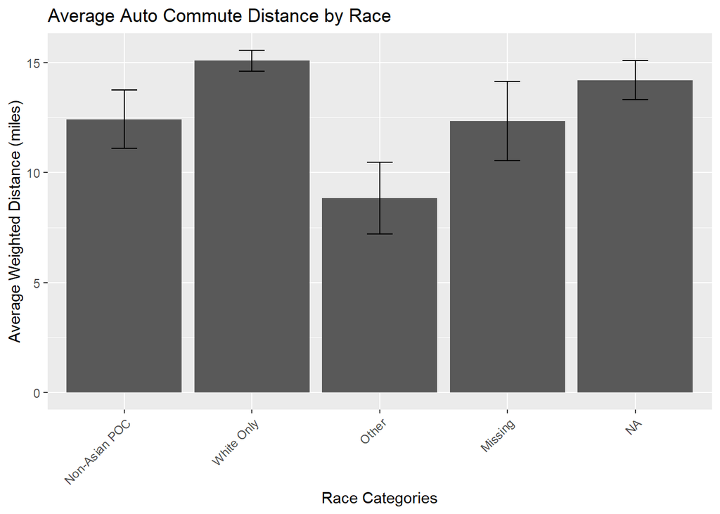

###### African American, Hispanic, and Other

For this analysis, respondents who identified as African American, Hispanic, and Other were aggregated.

The margin of error for the POC group is better than when African American-, Hispanic-, and Other-identifying individuals were analyzed separately. Unlike the previous aggregation, this group is now distinct from respondents identifying as Asian.

The average commuting distance by race:

| race_agg_2 | n | Group_weight | Weighted_percent | Weighted_avg | sd | se | CI_90 | CI_95 |
| --- | --- | --- | --- | --- | --- | --- | --- | --- |
| Non-Asian POC | 307 | 244217 | 15.35 | 10.98 | 9.147 | 0.522 | 0.859 | 1.023 |
| White Only | 1873 | 957188 | 60.17 | 15.08 | 10.571 | 0.244 | 0.402 | 0.479 |
| Missing | 142 | 218520 | 13.74 | 12.33 | 10.964 | 0.920 | 1.514 | 1.803 |
| NA | 382 | 170852 | 10.74 | 14.19 | 8.860 | 0.453 | 0.746 | 0.889 |

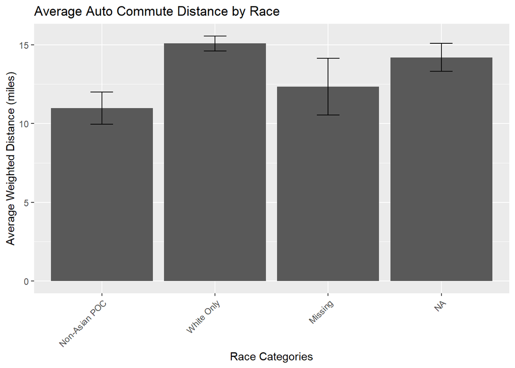

#### 3. Gender

People who identify as another gender have the shortest commute distances (sample size?), followed by females. People who identify as male have the longest commutes (15 miles).

The average commuting distance by gender:

| gender | n | Group_weight | Weighted_percent | Weighted_avg | sd | se | CI_90 | CI_95 |
| --- | --- | --- | --- | --- | --- | --- | --- | --- |
| Another | 15 | 4570 | 0.29 | 8.45 | 4.280 | 1.105 | 1.818 | 2.166 |
| Female | 1297 | 742163 | 46.65 | 12.64 | 9.246 | 0.257 | 0.422 | 0.503 |
| Male | 1364 | 825469 | 51.89 | 15.23 | 11.039 | 0.299 | 0.492 | 0.586 |
| Prefer not to answer | 28 | 18576 | 1.17 | 13.06 | 12.168 | 2.300 | 3.783 | 4.507 |

Because of the small sample sizes for respondents identifying as Another or choosing not to answer, these were removed from the graph:

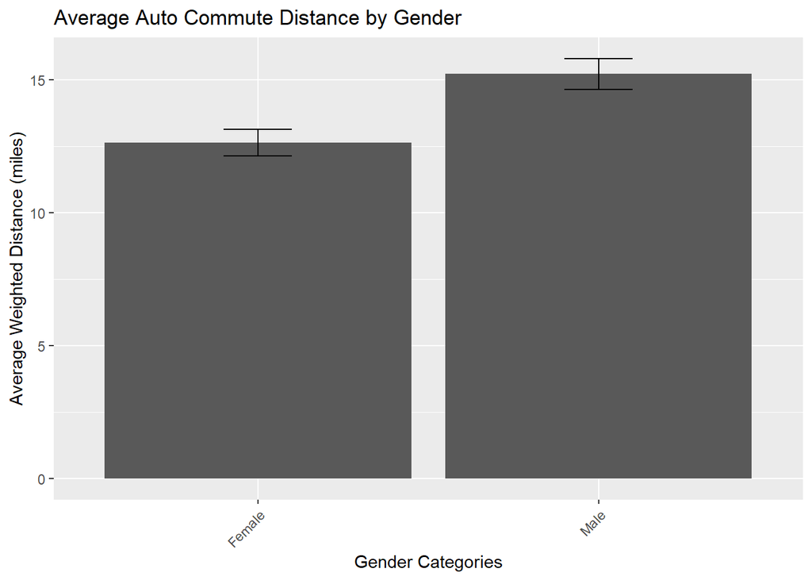

### **Commute duration**

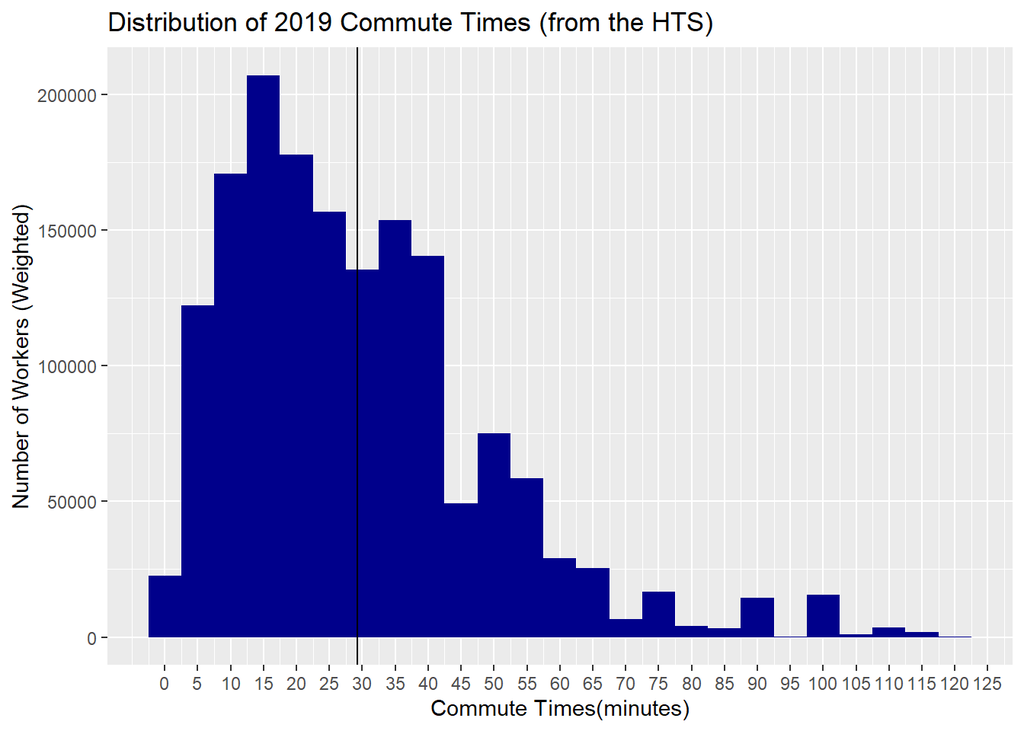

*The vertical line at x=**29.30 minutes** represents the mean commute duration for workers*

Share of workers with auto commutes

| time_bins | HouseholdWeight | WeightedPercent | WeightedAvg | min | max | SampleSize | SamplePercent |
| --- | --- | --- | --- | --- | --- | --- | --- |
| <10 minutes | 235435 | 14.80 | 6.46 | 0.033 | 9.983 | 634 | 23.45 |
| 10-20 minutes | 391939 | 24.64 | 15.35 | 10.000 | 19.967 | 755 | 27.92 |
| 20-30 minutes | 300661 | 18.90 | 25.15 | 20.000 | 29.967 | 577 | 21.34 |
| 30-45 minutes | 372108 | 23.39 | 36.68 | 30.000 | 44.783 | 503 | 18.60 |
| 45-60 minutes | 177814 | 11.18 | 51.05 | 45.067 | 59.767 | 138 | 5.10 |
| 60+ minutes | 112820 | 7.09 | 77.89 | 60.017 | 118.550 | 97 | 3.59 |

#### 1. Income

The average commuting duration by income:

| hhincome_detailed | n | Group_weight | Weighted_percent | Weighted_avg | sd | se | CI_90 | CI_95 |
| --- | --- | --- | --- | --- | --- | --- | --- | --- |
| Under $10,000 | 12 | 12928 | 0.81 | 13.91 | 9.799 | 2.829 | 4.653 | 5.544 |
| $10,000-$24,999 | 70 | 56470 | 3.55 | 19.66 | 13.581 | 1.623 | 2.670 | 3.182 |
| $25,000-$34,999 | 111 | 60586 | 3.81 | 20.20 | 11.983 | 1.137 | 1.871 | 2.229 |
| $35,000-$49,999 | 199 | 113998 | 7.17 | 24.03 | 14.550 | 1.031 | 1.697 | 2.022 |
| $50,000-$74,999 | 366 | 211106 | 13.27 | 26.77 | 17.463 | 0.913 | 1.502 | 1.789 |
| $75,000-$99,999 | 375 | 190867 | 12.00 | 32.95 | 19.378 | 1.001 | 1.646 | 1.961 |
| $100,000-$149,999 | 602 | 313578 | 19.71 | 30.25 | 15.928 | 0.649 | 1.068 | 1.272 |
| $150,000-$199,999 | 315 | 254263 | 15.98 | 33.05 | 16.992 | 0.957 | 1.575 | 1.876 |
| $200,000-$249,999 | 233 | 117506 | 7.39 | 33.53 | 14.180 | 0.929 | 1.528 | 1.821 |
| $250,000 or more | 220 | 78718 | 4.95 | 33.53 | 17.268 | 1.164 | 1.915 | 2.282 |

[output cut: 1 more lines]

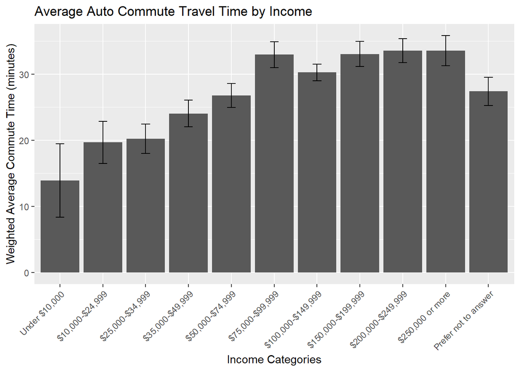

#### 2. Race

People who identify with by a race other than African American, Asian, Hispanic or White have the shortest commutes at about 18 minutes. African American, Asian, Hispanic, and White Only workers all have commutes around 30 minutes long.

The average commuting duration by race:

| race_category | n | Group_weight | Weighted_percent | Weighted_avg | sd | se | CI_90 | CI_95 |
| --- | --- | --- | --- | --- | --- | --- | --- | --- |
| African American | 66 | 59789 | 3.76 | 26.30 | 15.530 | 1.912 | 3.145 | 3.747 |
| Asian | 382 | 170852 | 10.74 | 30.83 | 14.514 | 0.743 | 1.222 | 1.455 |
| Hispanic | 122 | 86397 | 5.43 | 29.37 | 15.612 | 1.413 | 2.325 | 2.770 |
| Missing | 142 | 218520 | 13.74 | 28.92 | 16.660 | 1.398 | 2.300 | 2.740 |
| Other | 119 | 98030 | 6.16 | 17.85 | 15.971 | 1.464 | 2.408 | 2.870 |
| White Only | 1873 | 957188 | 60.17 | 30.47 | 16.983 | 0.392 | 0.646 | 0.769 |

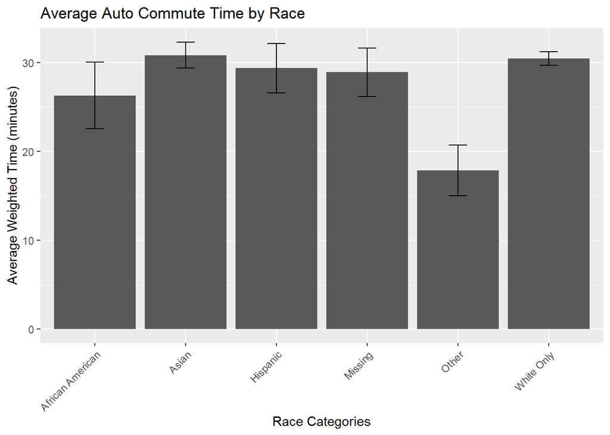

##### Aggregated Race

Because of small sample sizes, some of the respondents have been aggregated.

###### African American and Hispanic

For this analysis, respondents who identified as African American and Hispanic were aggregated.

Although the margin of error for the POC group is better than when African American- and Hispanic-identifying individuals were analyzed separately, it is still not distinct from respondents identifying as Asian.

| race_agg_1 | n | Group_weight | Weighted_percent | Weighted_avg | sd | se | CI_90 | CI_95 |
| --- | --- | --- | --- | --- | --- | --- | --- | --- |
| Non-Asian POC | 188 | 146186 | 9.19 | 28.11 | 15.542 | 1.134 | 1.865 | 2.222 |
| White Only | 1873 | 957188 | 60.17 | 30.47 | 16.983 | 0.392 | 0.646 | 0.769 |
| Other | 119 | 98030 | 6.16 | 17.85 | 15.971 | 1.464 | 2.408 | 2.870 |
| Missing | 142 | 218520 | 13.74 | 28.92 | 16.660 | 1.398 | 2.300 | 2.740 |
| NA | 382 | 170852 | 10.74 | 30.83 | 14.514 | 0.743 | 1.222 | 1.455 |

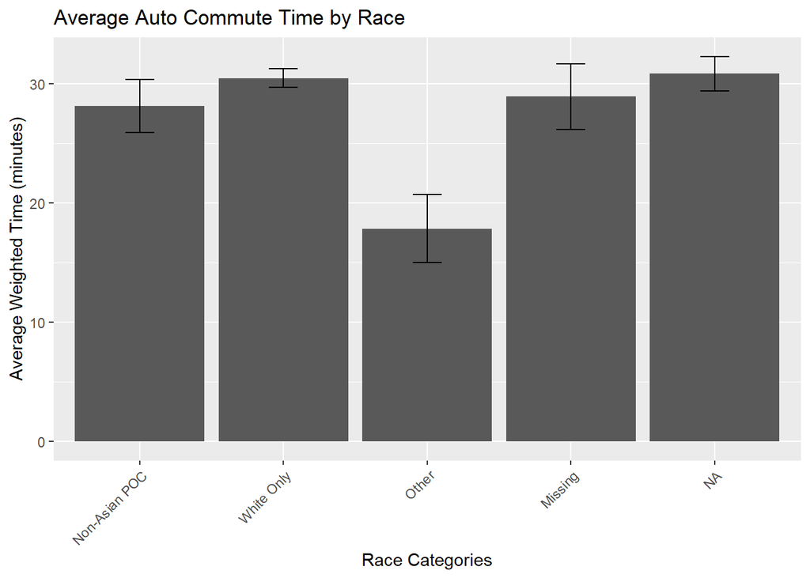

###### African American, Hispanic, and Other

For this analysis, respondents who identified as African American, Hispanic, and Other were aggregated.

The margin of error for the POC group is better than when African American-, Hispanic-, and Other-identifying individuals were analyzed separately. Unlike the previous aggregation, this group is now distinct from respondents identifying as Asian.

| race_agg_2 | n | Group_weight | Weighted_percent | Weighted_avg | sd | se | CI_90 | CI_95 |
| --- | --- | --- | --- | --- | --- | --- | --- | --- |
| Non-Asian POC | 307 | 244217 | 15.35 | 23.99 | 15.692 | 0.896 | 1.473 | 1.755 |
| White Only | 1873 | 957188 | 60.17 | 30.47 | 16.983 | 0.392 | 0.646 | 0.769 |
| Missing | 142 | 218520 | 13.74 | 28.92 | 16.660 | 1.398 | 2.300 | 2.740 |
| NA | 382 | 170852 | 10.74 | 30.83 | 14.514 | 0.743 | 1.222 | 1.455 |

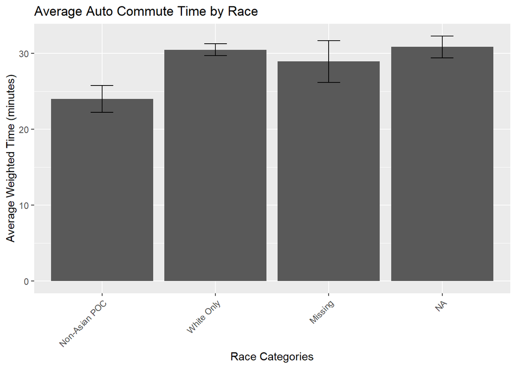

#### 3. Gender

| gender | n | Group_weight | Weighted_percent | Weighted_avg | sd | se | CI_90 | CI_95 |
| --- | --- | --- | --- | --- | --- | --- | --- | --- |
| Another | 15 | 4570 | 0.29 | 17.74 | 8.704 | 2.247 | 3.697 | 4.405 |
| Female | 1297 | 742163 | 46.65 | 27.46 | 15.803 | 0.439 | 0.722 | 0.860 |
| Male | 1364 | 825469 | 51.89 | 31.20 | 17.204 | 0.466 | 0.766 | 0.913 |
| Prefer not to answer | 28 | 18576 | 1.17 | 21.21 | 15.875 | 3.000 | 4.935 | 5.880 |

Because of the small sample sizes for respondents identifying as Another or choosing not to answer, these were removed from the graph:

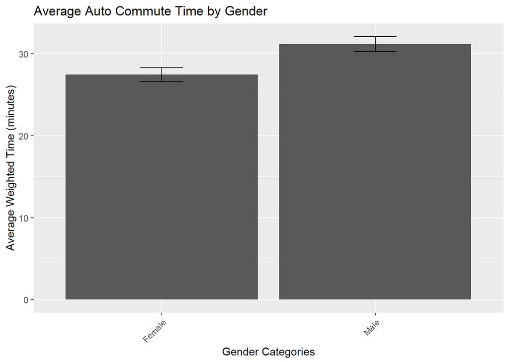

## Multiple Variables

### **Commute Distance: Race and Gender**

#### All Race Categories

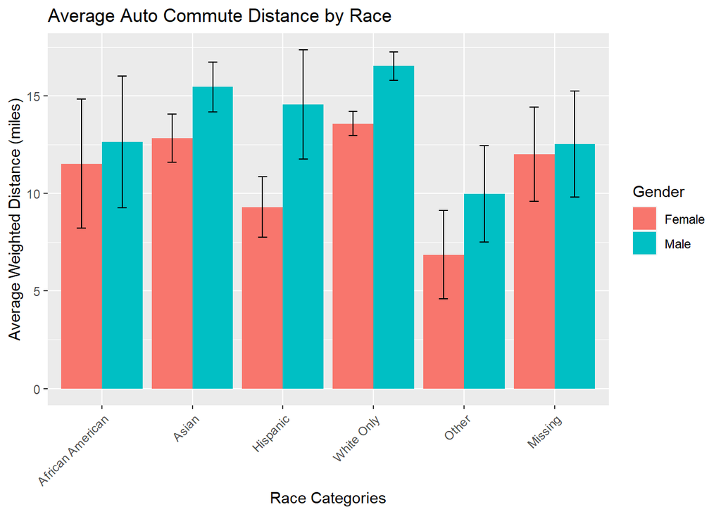

#### Aggregated Race Categories

Respondents who identified as African American and Hispanic were aggregated.

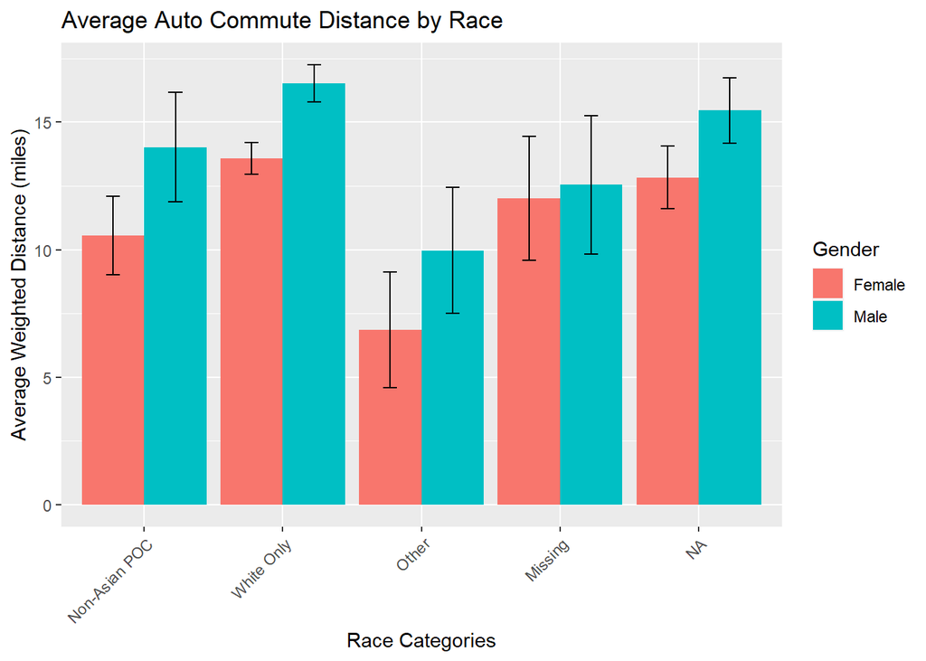

#### Further Aggregated Race Categories

Respondents who identified as African American, Hispanic, or Other were aggregated.

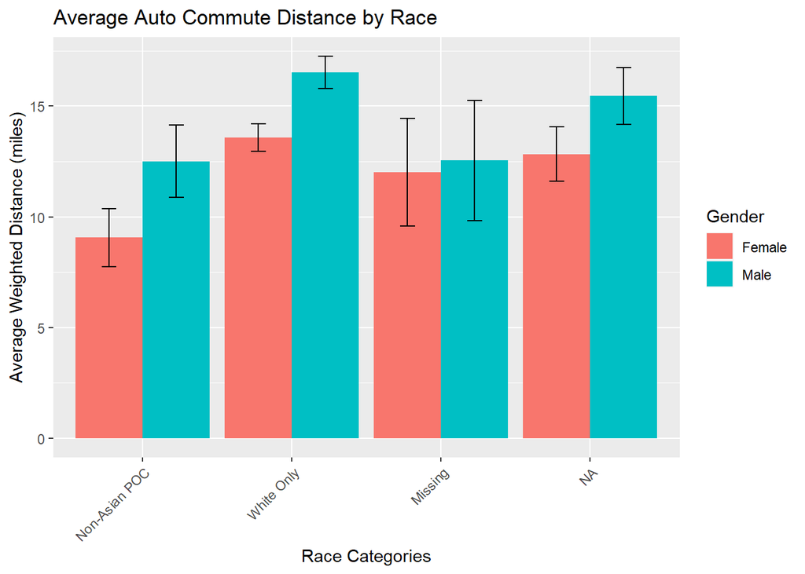

### **Commute Distance: Income and Race**

#### All Race Categories

For this analysis, broader income categories were used for easier visualization. The respondents who chose “Prefer not to answer” when asked for income were removed from this analysis.

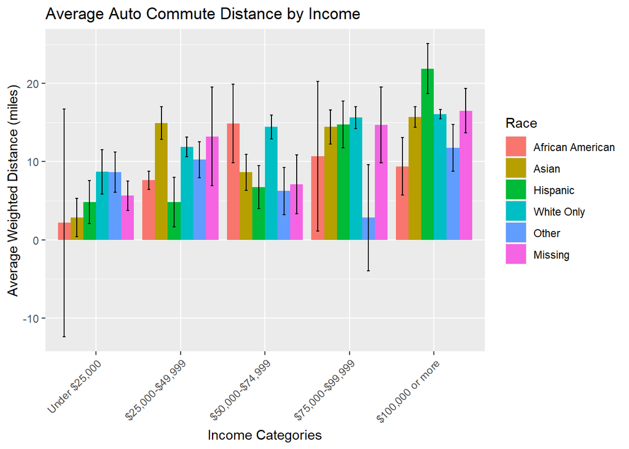

#### Aggregated Race Categories

Respondents who identified as African American and Hispanic were aggregated.

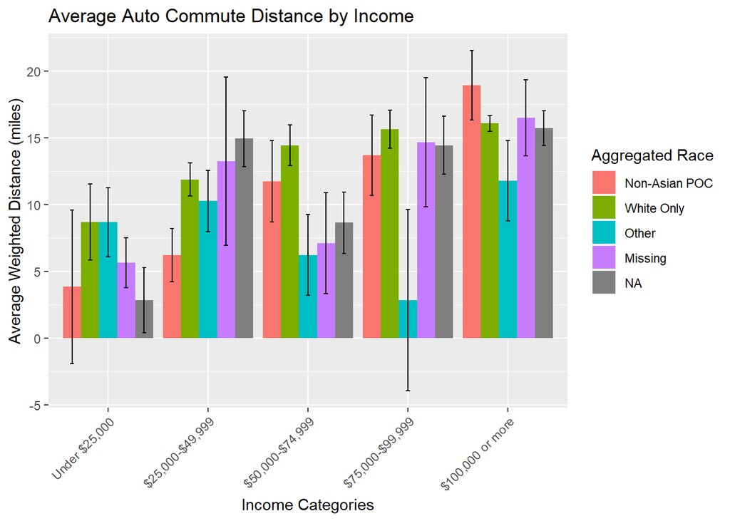

#### Further Aggregated Race Categories

Respondents who identified as African American, Hispanic, or Other were aggregated.

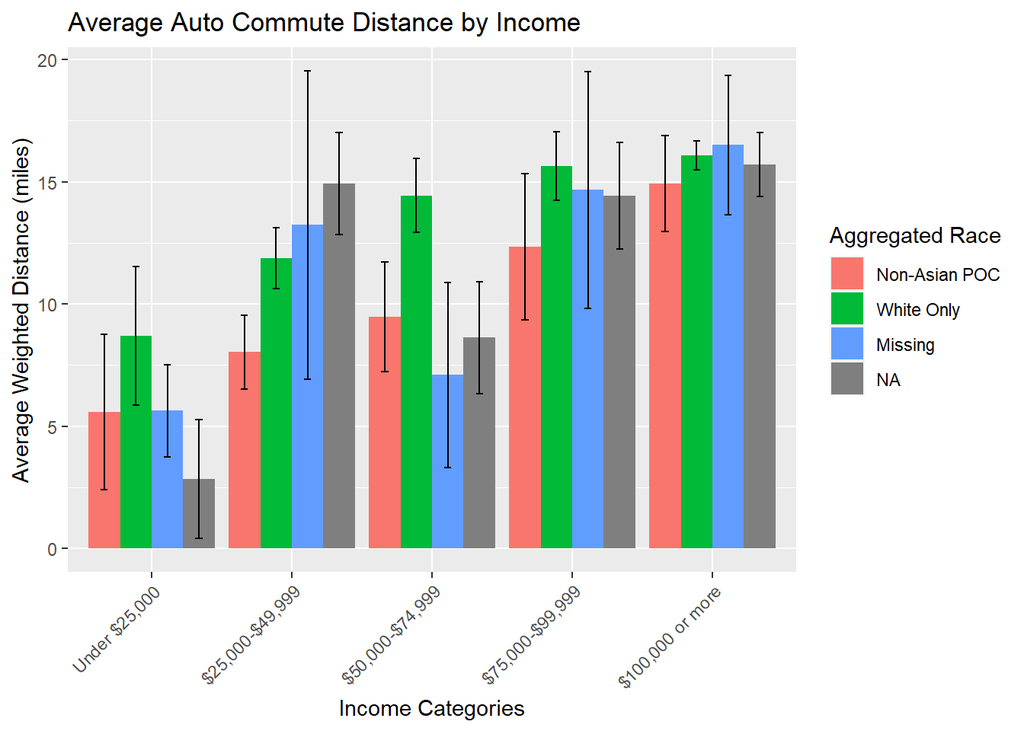

### **Commute Distance: Income and Gender**

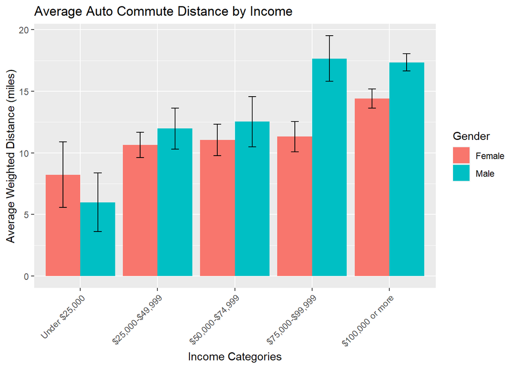

## Trends in Travel Time

The following table uses ACS data

| Counties | y_1980 | y_1990 | y_2000 | y_2010 | y_2018 |
| --- | --- | --- | --- | --- | --- |
| King | 23 | 24.2 | 25.3 | 26.1 | 30.2 |
| Kitsap | 25 | 25.1 | 31 | 29.2 | 30 |
| Pierce | 21.4 | 24 | 27.4 | 27.7 | 33.7 |
| Snohomish | 23.5 | 25.4 | 28.5 | 28.2 | 33.3 |
| Region | 22.9 | 24.4 | 26.7 | 27 | 31.5 |

Travel time to work has increased in our region since 1980 from about 23 minutes to 32 minutes in 2018.

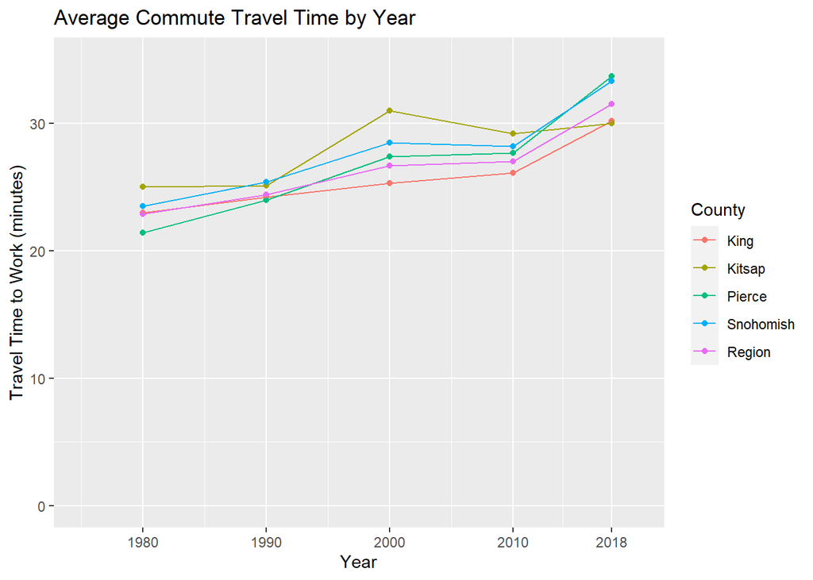

## Background: Sample

### Employment Status

The following table shows the distribution of respondents’ employment status.

| employment | SampleSize | Weighted_2019 | WeightedPercent | MOE |
| --- | --- | --- | --- | --- |
| Employed full time (35+ hours/week, paid) | 2811 | 1687954 | 53.89 | 1.18 |
| Employed part time (fewer than 35 hours/week, paid) | 428 | 274028 | 8.75 | 1.18 |
| Self-employed | 346 | 166300 | 5.31 | 1.18 |
| Unpaid volunteer or intern | 32 | 13127 | 0.42 | 1.18 |
| Homemaker | 170 | 183598 | 5.86 | 1.18 |
| Retired | 810 | 571258 | 18.24 | 1.18 |
| Not currently employed | 313 | 235731 | 7.53 | 1.18 |

### Workplace

The following table shows where workers go for work.

| workplace | SampleSize | Weighted_2019 | WeightedPercent | MOE |
| --- | --- | --- | --- | --- |
| At home (telecommute or self-employed with home office) | 271 | 136682 | 6.42 | 1.38 |
| Drives for a living (e.g., bus driver, salesperson) | 78 | 75233 | 3.53 | 1.38 |
| Usually the same location (outside home) | 2668 | 1505449 | 70.74 | 1.38 |
| Workplace regularly varies (different offices or jobsites) | 568 | 410918 | 19.31 | 1.38 |